# Umer Saeed

### swapcase

- Convert uppercase characters to lowercase and lowercase characters to uppercas

```python
a = 'have a nice day. my name is UMer Saeed'
print(a.swapcase())
```

```
HAVE A NICE DAY. MY NAME IS umER sAEED
```

### strip

- Return a copy of the string with leading and trailing whitespace remove.

```python
a = '       have a nice day. my name is UMer Saeed.       '
a
```

```
'       have a nice day. my name is UMer Saeed.       '
```

```python
print(a.strip())
```

```
have a nice day. my name is UMer Saeed.
```

```python
a = '       have a nice day.       my name is UMer Saeed.       '
print(a.strip())
```

```
have a nice day.       my name is UMer Saeed.
```

### split

- Return a list of the words in the string, using sep as the delimiter string.

```python
a = 'have a nice day. my name is UMer Saeed'
print(a.split())
```

```
['have', 'a', 'nice', 'day.', 'my', 'name', 'is', 'UMer', 'Saeed']
```

```python
a = 'have a nice day. my name is UMer Saeed'
print(a.split('.'))
```

```
['have a nice day', ' my name is UMer Saeed']
```

### rsplit

- Return a list of the words in the string, using sep as the delimiter string.

```python
a = 'have a nice day. my name is UMer Saeed.'
print(a.rsplit())
```

```
['have', 'a', 'nice', 'day.', 'my', 'name', 'is', 'UMer', 'Saeed.']
```

### rpartition

- Partition the string into three parts using the given separator.
- This will search for the separator in the string, starting at the end. If the separator is found, returns a 3-tuple containing the part before the separator, the separator itself, and the part after it.
- If the separator is not found, returns a 3-tuple containing two empty strings and the original string.

```python
a = 'have a nice day. my name is UMer Saeed. Hello Corvit. Hi Moto'
print(a.rpartition('.'))
```

```
('have a nice day. my name is UMer Saeed. Hello Corvit', '.', ' Hi Moto')
```

### rfind

- Return the highest index

```python
a = 'have a nice day. my name is UMer Saeed. Hello Corvit. Hi Moto'
print(a.rfind('y'))
```

```
18
```

### find

- Return the lowest index

```python
a = 'have a nice day. my name is UMer Saeed. Hello Corvit. Hi Moto'
print(a.find('y'))
```

```
14
```

### replace

- Return a copy with all occurrences of substring old replaced by new.

```python
a = 'have a nice day. my name is UMer Saeed. Hello Corvit. Hi Moto'
print(a.replace(' ','$'))
```

```
have$a$nice$day.$my$name$is$UMer$Saeed.$Hello$Corvit.$Hi$Moto
```

### partition

- Partition the string into three parts using the given separator.
- This will search for the separator in the string. If the separator is found, returns a 3-tuple containing the part before the separator, the separator itself, and the part after it.
- If the separator is not found, returns a 3-tuple containing the original string and two empty strings.

```python
a = 'have a nice, day. my name is UMer Saeed. Hello Corvit. Hi Moto'
print(a.partition(','))
```

```
('have a nice', ',', ' day. my name is UMer Saeed. Hello Corvit. Hi Moto')
```

### lstrip

- Return a copy of the string with leading whitespace removed.

```python
a = line = '       have a nice day.       my name is UMer Saeed.    '
print(a.lstrip())
```

```
have a nice day.       my name is UMer Saeed.
```

### isprintable

- Return True if the string is printable, False otherwise.

```python
a ='hello \t, i am Umer Saeed'
print(a.isprintable())
```

```
False
```

```python
a ='hello, i am Umer Saeed'
print(a.isprintable())
```

```
True
```

### isnumeric

```python
a ='hello, i am Umer Saeed'
print(a.isnumeric())
```

```
False
```

```python
a ='796096'
print(a.isnumeric())
```

```
True
```

### isidentifier

- Return True if the string is a valid Python identifier, False otherwise.

```python
a ='796096'
print(a.isidentifier())
```

```
False
```

```python
a ='True'
print(a.isidentifier())
```

```
True
```

```python
a ='None'
print(a.isidentifier())
```

```
True
```

```python
a ='if'
print(a.isidentifier())
```

```
True
```

### isdigit

```python
a ='796096'
print(a.isdigit())
```

```
True
```

```python
a ='796096.63'
print(a.isdigit())
```

```
False
```

```python
a ='My Name is Umer Saeed'
print(a.isdigit())
```

```
False
```

### isdecimal

```python
a ='796096'
print(a.isdecimal())
```

```
True
```

```python
a ='796096.63'
print(a.isdecimal())
```

```
False
```

```python
dir(a)
```

```
['__add__',
 '__class__',
 '__contains__',
 '__delattr__',
 '__dir__',
 '__doc__',
 '__eq__',
 '__format__',
 '__ge__',
 '__getattribute__',
 '__getitem__',
 '__getnewargs__',
 '__gt__',
 '__hash__',
 '__init__',
 '__init_subclass__',
 '__iter__',
 '__le__',
 '__len__',
 '__lt__',
 '__mod__',
 '__mul__',
 '__ne__',
 '__new__',
 '__reduce__',
 '__reduce_ex__',
 '__repr__',
 '__rmod__',
 '__rmul__',
 '__setattr__',
 '__sizeof__',
 '__str__',
 '__subclasshook__',
 'capitalize',
 'casefold',
 'center',
 'count',
 'encode',
 'endswith',
 'expandtabs',
```

[output cut: 23 more lines]

```
 'rfind',
 'rindex',
 'rjust',
 'rpartition',
 'rsplit',
 'rstrip',
 'split',
 'splitlines',
 'startswith',
 'strip',
 'swapcase',
 'title',
 'translate',
 'upper',
 'zfill']
```

### String Formatting Operator

```python
YouTubeVideo('z4aqaH0kTWs',width=900, height=500)
```

[video not shown]

- [More information](https://www.programiz.com/python-programming/methods/string/format)
- The % symbol has special meaning in Python strings.
- It can be used as a placeholder for another value to be inserted into the string
- The % symbol is a prefix to another character which defines the type of value to be inserted
- So we used %s where we wanted to insert a string and %i for an integer.
- The values are provided after the % after the end of the string.

```python
print("Hello %s, you scored %i out of %i" % ("Ali", 90, 100))
```

```
Hello Ali, you scored 90 out of 100
```

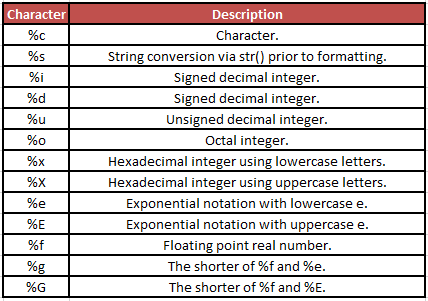

```python
Image(filename='StringFormattingOperator.png')
```

### Example 1: Basic formatting for default, positional and keyword arguments

```python
# default arguments
print("Hello {}, your balance is {}.".format("Umer", 230.2346))

# positional arguments
print("Hello {0}, your balance is {1}.".format("Ali", 230.2346))

# keyword arguments
print("Hello {name}, your balance is {blc}.".format(name="Ahmed", blc=230.2346))

# mixed arguments
print("Hello {0}, your balance is {blc}.".format("Awais", blc=230.2346))
```

```
Hello Umer, your balance is 230.2346.
Hello Ali, your balance is 230.2346.
Hello Ahmed, your balance is 230.2346.
Hello Awais, your balance is 230.2346.
```

### Example 2: Simple number formatting

```python
# integer arguments
print("The number is:{:d}".format(123))

# float arguments
print("The float number is:{:f}".format(123.4567898))

# octal, binary and hexadecimal format
print("bin: {0:b}, oct: {0:o}, hex: {0:x}".format(12))
```

```
The number is:123
The float number is:123.456790
bin: 1100, oct: 14, hex: c
```

### Example 3: Number formatting with padding for int and floats

```python
# integer numbers with minimum width
print("{:5d}".format(12))

# width doesn't work for numbers longer than padding
print("{:2d}".format(1234))

# padding for float numbers
print("{:8.3f}".format(12.2346))

# integer numbers with minimum width filled with zeros
print("{:05d}".format(12))

# padding for float numbers filled with zeros
print("{:08.3f}".format(12.2346))
```

```
   12
1234
  12.235
00012
0012.235
```

### Example 4: Number formatting for signed numbers

```python
# show the + sign
print("{:+f} {:+f}".format(12.23, -12.23))

# show the - sign only
print("{:-f} {:-f}".format(12.23, -12.23))

# show space for + sign
print("{: f} {: f}".format(12.23, -12.23))
```

```
+12.230000 -12.230000
12.230000 -12.230000
 12.230000 -12.230000
```

### Example 5: Number formatting with left, right and center alignment

```python
# integer numbers with right alignment
print("{:5d}".format(12))

# float numbers with center alignment
print("{:^10.3f}".format(12.2346))

# integer left alignment filled with zeros
print("{:<05d}".format(12))

# float numbers with center alignment
print("{:=8.3f}".format(-12.2346))
```

```
   12
  12.235
12000
- 12.235
```

### Example 6: String formatting with padding and alignment

```python
# string padding with left alignment
print("{:5}".format("cat"))

# string padding with right alignment
print("{:>5}".format("cat"))

# string padding with center alignment
print("{:^5}".format("cat"))

# string padding with center alignment
# and '*' padding character
print("{:*^5}".format("cat"))
```

```
cat
  cat
 cat
*cat*
```

### Example 7: Truncating strings with format()

```python
# truncating strings to 3 letters
print("{:.3}".format("caterpillar"))

# truncating strings to 3 letters
# and padding
print("{:5.3}".format("caterpillar"))

# truncating strings to 3 letters,
# padding and center alignment
print("{:^5.3}".format("caterpillar"))
```

```
cat
cat
 cat
```

### Example 8: Formatting dictionary members using format()

```python
# define Person dictionary
person = {'age': 36, 'name': 'Hamza'}

# format age
print("{p[name]}'s age is: {p[age]}".format(p=person))
```

```
Hamza's age is: 36
```

- There's an easier way to format dictionaries in Python using str.format(**mapping).

```python
# define Person dictionary
person = {'age': 23, 'name': 'Hamza'}

# format age
print("{name}'s age is: {age}".format(**person))
```

```
Hamza's age is: 23
```

### Example 9: Dynamic formatting using format()

```python
# dynamic string format template
string = "{:{fill}{align}{width}}"

# passing format codes as arguments
print(string.format('cat', fill='*', align='^', width=5))

# dynamic float format template
num = "{:{align}{width}.{precision}f}"

# passing format codes as arguments
print(num.format(123.236, align='<', width=8, precision=2))
```

```
*cat*
123.24
```

# Chapter 5: Python Collections

- There are four collection data types in the Python programming language:
- 1- List is a collection which is ordered and changeable. Allows duplicate members.
- 2- Tuple is a collection which is ordered and unchangeable. Allows duplicate members.
- 3- Set is a collection which is unordered and unindexed. No duplicate members.
- 4- Dictionary is a collection which is unordered, changeable and indexed. No duplicate members.

# 5.1 Lists

```python
YouTubeVideo('Eaz5e6M8tL4',width=900, height=500)
```

[video not shown]

- Like a string, a list is a sequence of values.
- In a string, the values are characters; in a list, they can be any type.
- The values in list are called elements or sometimes items.
- There are several ways to create a new list; the simplest is to enclose the elements in square brackets ([ and ]).

### Example-1

- The first example is a list of four integers.

```python
a=[10, 20, 30, 40]
type(a)
```

```
list
```

### Example-2

- The second example is a list of three strings.

```python
a=['Umer Saeed', 'Ali Saeed', 'Ahmed Abdullah Saeed']
type(a)
```

```
list
```

- The elements of a list don’t have to be the same type.
- The following list contains a string, a float, an integer.

```python
a=['Python',2,3.7]
type(a)
```

```
list
```

### Nested List

- A list within another list is nested list.

```python
a=['Ali Saeed',5.2,[1,3,7]]
type(a)
```

```
list
```

### Empty List

- A list that contains no elements is called an empty list.
- You can create one with empty brackets, [].

```python
name=['Umer Saeed', 'Ali Saeed', 'Ahmed Abdullah Saeed']
number=[98,99,100]
results=[]
print(name,number,results)
```

```
['Umer Saeed', 'Ali Saeed', 'Ahmed Abdullah Saeed'] [98, 99, 100] []
```

```python
mylist=[name,number]
mylist
```

```
[['Umer Saeed', 'Ali Saeed', 'Ahmed Abdullah Saeed'], [98, 99, 100]]
```

### List slices

- The syntax for accessing the elements of a list is the same as for accessing the characters of a string: the bracket operator.
- The expression inside the brackets specifies the index.
- Remember that the indices start at 0.

### Example-1

```python
a=['hotmail', 'yahoomail', 'gmail']
a[0]
```

```
'hotmail'
```

### Example-2

- Any integer expression can be used as an index.

```python
a=['UET','UMT','UCP']
a[0]
```

```
'UET'
```

### Example-3

- If you try to read or write an element that does not exist, you get an IndexError.

```python
a=['UET','UMT','UCP']
a[5]
```

```
---------------------------------------------------------------------------
IndexError                                Traceback (most recent call last)
<ipython-input-309-0d0f292226b5> in <module>
      1 a=['UET','UMT','UCP']
----> 2 a[5]

IndexError: list index out of range
```

### Example-4

- If an index has a negative value, it counts backward from the end of the list.

```python
a=['UET','UMT','UCP']
a[-2]
```

```
'UMT'
```

### Example-5

```python
a=['UET','UMT','UCP']
a[0:1]
```

```
['UET']
```

### Example-6

```python
a=['UET','UMT','UCP']
a[:2]
```

```
['UET', 'UMT']
```

### Example-7

```python
a=['UET','UMT','UCP']
a[:]
```

```
['UET', 'UMT', 'UCP']
```

### Lists are mutable

- Lists are mutable because you can change the order of items in a list or reassign an item in a list.
- When the bracket operator appears on the left side of an assignment, it identifies the element of the list that will be assigned.

### Example-1

```python
number=[98,99,100]
number[0]=100
print(number)
```

```
[100, 99, 100]
```

- The one-eth element of numbers, which used to be 98, is now 100.
- You can think of a list as a relationship between indices and elements. This relationship is called a mapping; each index “maps to” one of the elements.

### Example-2

```python
a=['a','b','c','d','e']
a[0:3]=['x','y','z']
print(a)
```

```
['x', 'y', 'z', 'd', 'e']
```

### in operator

### Example-1

```python
a=['UET','UMT','UCP']
'UET' in a
```

```
True
```

```python
a=['UET','UMT','UCP']
'GCU' in a
```

```
False
```

### + operator

- The + operator concatenates lists:

```python
a=[1,2,3]
b=[4,5]
c=a+b
print(c)
```

```
[1, 2, 3, 4, 5]
```

### * operator

- The * operator repeats a list a given number of times

```python
[0] * 4
```

```
[0, 0, 0, 0]
```

```python
[1, 2, 3] * 3
```

```
[1, 2, 3, 1, 2, 3, 1, 2, 3]
```

- On the other hand, division (/) and subtraction (-) give only errors

### append

```python
a=['a','b','c','d']
a.append('e')
print(a)
```

```
['a', 'b', 'c', 'd', 'e']
```

### insert

```python
a = ["apple", "banana", "cherry"]
a.insert(0, "orange")
print(a)
```

```
['orange', 'apple', 'banana', 'cherry']
```

### extend

```python
a=['a','b','c']
b=['d','e','f']
a.extend(b)
print(a)
```

```
['a', 'b', 'c', 'd', 'e', 'f']
```

### sort

```python
a=['x','y','z']
b=['d','e','f']
a.extend(b)
a.sort()
print(a)
```

```
['d', 'e', 'f', 'x', 'y', 'z']
```

- sort arranges the elements of the list from high to low:

```python
a=['d','a','e']
b=['b','c']
a.extend(b)
a.sort(reverse=True)
print(a)
```

```
['e', 'd', 'c', 'b', 'a']
```

- Most list methods are void; they modify the list and return None. If you accidentally write t = t.sort(), you will be disappointed with the result.

```python
t1=['d','a','e']
t2=['b','c']
t1.extend(t2)
t1=t1.sort(reverse=True)
print(t1)
```

```
None
```

### Solution

```python
t1=['d','a','e']
t2=['b','c']
t1.extend(t2)
t1=sorted(t1,reverse=True)
print(t1)
```

```
['e', 'd', 'c', 'b', 'a']
```

### reverse

```python
name=['Umer','Ali','Ahmed','Bilal','Irfan','Ijlal']
name.reverse()
name
```

```
['Ijlal', 'Irfan', 'Bilal', 'Ahmed', 'Ali', 'Umer']
```

### Deleting elements

- There are several ways to delete elements from a list.

### 1- pop

If you know the index of the element you want, you can use pop:

```python
t=['a','b','c']
a=t.pop(2)
print(a)
print(t)
```

```
c
['a', 'b']
```

- If you don’t provide an index, it deletes and returns the last element

```python
t=['a','b','c','d','e']
a=t.pop()
print(a)
print(t)
```

```
e
['a', 'b', 'c', 'd']
```

### 2-del operator

- If you don’t need the removed value, you can use the del operator, To remove more than one element, you can use del with a slice index. As usual, the slice selects all the elements up to, but not including, the second index.

```python
t=['a','b','c','d','e']
del t[1:3]
print(t)
```

```
['a', 'd', 'e']
```

### 3- remove

- If you know the element you want to remove (but not the index), you can use remove:

```python
t = ['a','b','c','d','e']
t.remove('b')
print(t)
```

```
['a', 'c', 'd', 'e']
```

### 4- clear

- The clear() method empties the list:

```python
thislist = ["apple", "banana", "cherry"]
thislist.clear()
print(thislist)
```

```
[]
```

### Lists and functions

- There are a number of built-in functions that can be used on lists that allow you to quickly look through a list without writing your own loops:

```python
nums=[3,4,8,16,32,6]
print(len(nums))
print(sum(nums))
print(max(nums))
print(min(nums))
print(sum(nums)/len(nums))
```

```
6
69
32
3
11.5
```

- The sum() function only works when the list elements are numbers.
- The other functions (max(), len(), etc.) work with lists of strings and other types that can be comparable.

```python
etc=['hotmail','yahoo','gmail']
print(len(etc))
print(max(etc))
```

```
3
yahoo
```

### Lists and Strings

- A string is a sequence of characters and a list is a sequence of values, but a list of characters is not the same as a string.
- To convert from a string to a list of characters, you can use list:

```python
name='Umer Saeed'
t=list(name)
print(t)
```

```
['U', 'm', 'e', 'r', ' ', 'S', 'a', 'e', 'e', 'd']
```

- Because list is the name of a built-in function, you should avoid using it as a variable name.
- I also avoid the letter l because it looks too much like the number 1. So that’s why I use t.

### split method

- The list function breaks a string into individual letters.
- If you want to break a string into words, you can use the split method:

```python
message="Hello, My name is Umer Saeed"
t=message.split()
print(t)
t[2]
```

```
['Hello,', 'My', 'name', 'is', 'Umer', 'Saeed']
```

```
'name'
```

- Once you have used split to break the string into a list of words, you can use the index operator (square bracket) to look at a particular word in the list.

### delimiter

- You can call split with an optional argument called a delimiter that specifies which characters to use as word boundaries!

```python
universites="PU,UET,UMT,UCP,GCU"
delimiter=","
t=universites.split(delimiter)
print(t)
```

```
['PU', 'UET', 'UMT', 'UCP', 'GCU']
```

### join

- Join is the inverse of split.
- It takes a list of strings and concatenates the elements.
- join is a string method, so you have to invoke it on the delimiter and pass the list as a parameter.

```python
universites="PU","UET","UMT","UCP","GCU"
delimiter=" "
delimiter.join(universites)
```

```
'PU UET UMT UCP GCU'
```

- In this case the delimiter is a space character, so join puts a space between words.
- To concatenate strings without spaces, you can use the empty string, “”, as a delimiter.

```python
universites="PU","UET","UMT","UCP","GCU"
delimiter=""
delimiter.join(universites)
```

```
'PUUETUMTUCPGCU'
```

### Python List copy() Method

- The copy() method returns a copy of the specified list.

```python
name = ['Umer', 'Ali', 'Ahmed', 'Usman']
x=name.copy()
print(x)
```

```
['Umer', 'Ali', 'Ahmed', 'Usman']
```

### Python List count() Method

- The count() method returns the number of elements with the specified value.

```python
points = [1, 4, 2, 9, 7, 8, 9, 3, 1]
x = points.count(9)
print(x)
```

```
2
```

### Python List index() Method

- The index() method returns the position at the first occurrence of the specified value.

```python
digi = [4, 55, 64, 32, 16, 32]
x = digi.index(32)
print(x)
```

```
3
```

```python
dir(digi)
```

```
['__add__',
 '__class__',
 '__contains__',
 '__delattr__',
 '__delitem__',
 '__dir__',
 '__doc__',
 '__eq__',
 '__format__',
 '__ge__',
 '__getattribute__',
 '__getitem__',
 '__gt__',
 '__hash__',
 '__iadd__',
 '__imul__',
 '__init__',
 '__init_subclass__',
 '__iter__',
 '__le__',
 '__len__',
 '__lt__',
 '__mul__',
 '__ne__',
 '__new__',
 '__reduce__',
 '__reduce_ex__',
 '__repr__',
 '__reversed__',
 '__rmul__',
 '__setattr__',
 '__setitem__',
 '__sizeof__',
 '__str__',
 '__subclasshook__',
 'append',
 'clear',
 'copy',
 'count',
 'extend',
 'index',
 'insert',
 'pop',
 'remove',
 'reverse',
 'sort']
```

# 5.2 Dictionary

```python
YouTubeVideo('XCcpzWs-CI4',width=900, height=500)
```

[video not shown]

### Python Dictionaries

- A dictionary is a collection which is unordered, changeable and indexed. In Python dictionaries are written with curly brackets, and they have keys and values.

### Create and print a dictionary

```python
a ={
  "University": "University of Management and Technology",
  "School": "School of Business and Economics",
  "No of MS Programs": 11
}
```

```python
a
```

```
{'University': 'University of Management and Technology',
 'School': 'School of Business and Economics',
 'No of MS Programs': 11}
```

### The dict() Constructor

- It is also possible to use the dict() constructor to make a dictionary:

```python
a =dict(University="University of Management and Technology", School="School of Business and Economics",
               Department="Information Systems", Phd =20)
```

```python
a
```

```
{'University': 'University of Management and Technology',
 'School': 'School of Business and Economics',
 'Department': 'Information Systems',
 'Phd': 20}
```

### type

```python
type(a)
```

```
dict
```

### Accessing Items:

- You can access the items of a dictionary by referring to its key name, inside square brackets:

```python
a["School"]
```

```
'School of Business and Economics'
```

### get():

- There is also a method called get() that will give you the same result:

```python
a.get('School')
```

```
'School of Business and Economics'
```

### keys, values, items & Change Values

- You can change the value of a specific item by referring to its key name:

```python
a ={
  "University": "University of Management and Technology",
  "School": "School of Business and Economics",
  "No of MS Programs": 11
}
```

```python
a.keys()
```

```
dict_keys(['University', 'School', 'No of MS Programs'])
```

```python
a.values()
```

```
dict_values(['University of Management and Technology', 'School of Business and Economics', 11])
```

```python
a.items()
```

```
dict_items([('University', 'University of Management and Technology'), ('School', 'School of Business and Economics'), ('No of MS Programs', 11)])
```

```python
a["School"] = "School of Systems and Technology (SST)"
```

```python
a
```

```
{'University': 'University of Management and Technology',
 'School': 'School of Systems and Technology (SST)',
 'No of MS Programs': 11}
```

```python
a["School"]
```

```
'School of Systems and Technology (SST)'
```

### Dictionary Length

- To determine how many items (key-value pairs) a dictionary have, use the len() method.

```python
a ={
  "University": "University of Management and Technology",
  "School": "School of Business and Economics",
  "No of MS Programs": 11
}
```

```python
len(a)
```

```
3
```

### Adding Items

- Adding an item to the dictionary is done by using a new index key and assigning a value to it:

```python
a ={
  "University": "University of Management and Technology",
  "School": "School of Business and Economics",
  "No of MS Programs": 11
}
```

```python
a["No of Phd Faculty"] = 20
```

```python
print(a)
```

```
{'University': 'University of Management and Technology', 'School': 'School of Business and Economics', 'No of MS Programs': 11, 'No of Phd Faculty': 20}
```

```python
len(a)
```

```
4
```

### Removing Items

- There are several methods to remove items from a dictionary:

### 1-pop

```python
a ={
  "University": "University of Management and Technology",
  "School": "School of Business and Economics",
  "No of MS Programs": 11
}
```

```python
a.pop("School")
```

```
'School of Business and Economics'
```

```python
a
```

```
{'University': 'University of Management and Technology',
 'No of MS Programs': 11}
```

### 2-popitem

- The popitem() method removes the last inserted item

```python
a ={
  "University": "University of Management and Technology",
  "School": "School of Business and Economics",
  "No of MS Programs": 11
}
```

```python
a.popitem()
```

```
('No of MS Programs', 11)
```

### 3-del

- The del keyword removes the item with the specified key name:

```python
a ={
  "University": "University of Management and Technology",
  "School": "School of Business and Economics",
  "No of MS Programs": 11
}
```

```python
del a["School"]
```

```python
a
```

```
{'University': 'University of Management and Technology',
 'No of MS Programs': 11}
```

### 4-clear

- The clear() keyword empties the dictionary:

```python
a ={
  "University": "University of Management and Technology",
  "School": "School of Business and Economics",
  "No of MS Programs": 11
}
```

```python
a.clear()
```

```python
a
```

```
{}
```

### fromkeys

```python
a=[1,2,3,4]
dict.fromkeys(a)
```

```
{1: None, 2: None, 3: None, 4: None}
```

```python
{}.fromkeys(range(1,7),10)
```

```
{1: 10, 2: 10, 3: 10, 4: 10, 5: 10, 6: 10}
```

### setdefault

```python
student={'Umer':100,'Ali':98,'Ahmed':100}
```

```python
student.setdefault('Umer')
```

```
100
```

```python
student
```

```
{'Umer': 100, 'Ali': 98, 'Ahmed': 100}
```

```python
student.setdefault('Irfan')
```

```python
student
```

```
{'Umer': 100, 'Ali': 98, 'Ahmed': 100, 'Irfan': None}
```

```python
student.setdefault('Ijlal',97)
```

```
97
```

```python
student
```

```
{'Umer': 100, 'Ali': 98, 'Ahmed': 100, 'Irfan': None, 'Ijlal': 97}
```

### update

### Example-1

```python
student1={'Umer':100,'Ali':98,'Ahmed':100}
student2={'Irfan':100}
```

```python
student1.update(student2)
```

```python
student1
```

```
{'Umer': 100, 'Ali': 98, 'Ahmed': 100, 'Irfan': 100}
```

```python
student2
```

```
{'Irfan': 100}
```

### Example-2

```python
student1={'Umer':100,'Ali':98,'Ahmed':100}
student2=['Ijlal',100]
```

```python
student1.update([student2])
```

```python
student1
```

```
{'Umer': 100, 'Ali': 98, 'Ahmed': 100, 'Ijlal': 100}
```

```python
student2
```

```
['Ijlal', 100]
```

### Example-3

```python
student1={'Umer':100,'Ali':98,'Ahmed':100}
```

```python
student1.update(Bilal=100,Kashif=98, Zahid=99)
```

```python
student1
```

```
{'Umer': 100, 'Ali': 98, 'Ahmed': 100, 'Bilal': 100, 'Kashif': 98, 'Zahid': 99}
```

### Example-4

```python
student1={'Umer':100,'Ali':98,'Ahmed':100}
student2={'Umer':80}
student1.update(student2)
```

```python
student1
```

```
{'Umer': 80, 'Ali': 98, 'Ahmed': 100}
```

```python
student2
```

```
{'Umer': 80}
```

### Copy

```python
weather={'Lahore':48,'Karachi':45,'Isb':38}
x=weather.copy()
print(x)
```

```
{'Lahore': 48, 'Karachi': 45, 'Isb': 38}
```

```python
dir(x)
```

```
['__class__',
 '__contains__',
 '__delattr__',
 '__delitem__',
 '__dir__',
 '__doc__',
 '__eq__',
 '__format__',
 '__ge__',
 '__getattribute__',
 '__getitem__',
 '__gt__',
 '__hash__',
 '__init__',
 '__init_subclass__',
 '__iter__',
 '__le__',
 '__len__',
 '__lt__',
 '__ne__',
 '__new__',
 '__reduce__',
 '__reduce_ex__',
 '__repr__',
 '__setattr__',
 '__setitem__',
 '__sizeof__',
 '__str__',
 '__subclasshook__',
 'clear',
 'copy',
 'fromkeys',
 'get',
 'items',
 'keys',
 'pop',
 'popitem',
 'setdefault',
 'update',
 'values']
```

# 5.3 Tuples

```python
YouTubeVideo('wRC4H-k57eg',width=900, height=500)
```

[video not shown]

- A tuple is a collection which is ordered and unchangeable. In Python tuples are written with round brackets.

### Create a Tuple

```python
a = ("Umer Saeed", "Ali Saeed", "Ahmed Abdullah Saeed")
print(a)
```

```
('Umer Saeed', 'Ali Saeed', 'Ahmed Abdullah Saeed')
```

### The tuple() Constructor

- It is also possible to use the tuple() constructor to make a tuple.

```python
a = tuple(("Umer Saeed", "Ali Saeed", "Ahmed Abdullah Saeed"))                              # note the double round-brackets
print(a)
```

```
('Umer Saeed', 'Ali Saeed', 'Ahmed Abdullah Saeed')
```

### type

```python
type(a)
```

```
tuple
```

### Access Tuple Items

- You can access tuple items by referring to the index number, inside square brackets:

```python
a = ("Umer Saeed", "Ali Saeed", "Ahmed Abdullah Saeed")
a[0]
```

```
'Umer Saeed'
```

### Change Tuple Values

- Once a tuple is created, you cannot change its values. Tuples are unchangeable.

```python
a = ("Umer Saeed", "Ali Saeed", "Ahmed Abdullah Saeed")
```

```python
a[0]="Irfan Kareem"
```

```
---------------------------------------------------------------------------
TypeError                                 Traceback (most recent call last)
<ipython-input-408-fb0027075afd> in <module>
----> 1 a[0]="Irfan Kareem"

TypeError: 'tuple' object does not support item assignment
```

### Add Items

- Once a tuple is created, you cannot add items to it. Tuples are unchangeable.

```python
a = ("Umer Saeed", "Ali Saeed", "Ahmed Abdullah Saeed")
```

```python
a[3]="Muhammad Usman"
```

```
---------------------------------------------------------------------------
TypeError                                 Traceback (most recent call last)
<ipython-input-410-8ac1b74430b6> in <module>
----> 1 a[3]="Muhammad Usman"

TypeError: 'tuple' object does not support item assignment
```

### Remove Items

- Tuples are unchangeable, so you cannot remove items from it, but you can delete the tuple completely:
- The del keyword can delete the tuple completely:

```python
a = ("Umer Saeed", "Ali Saeed", "Ahmed Abdullah Saeed")
```

```python
del a
```

```python
a
```

```
---------------------------------------------------------------------------
NameError                                 Traceback (most recent call last)
<ipython-input-413-3f786850e387> in <module>
----> 1 a

NameError: name 'a' is not defined
```

### Tuple Length

- To determine how many items a list have, use the len() method:

```python
a = ("Umer Saeed", "Ali Saeed", "Ahmed Abdullah Saeed")
len(a)
```

```
3
```

### count

```python
a = (1, 4, 2, 9, 7, 8, 9, 3, 1)
x = a.count(9)
print(x)
```

```
2
```

### index

- Return first index of value.

```python
a = (1, 4, 2, 9, 7, 8, 9, 3, 1)
x = a.index(9)
print(x)
```

```
3
```

```python
dir(a)
```

```
['__add__',
 '__class__',
 '__contains__',
 '__delattr__',
 '__dir__',
 '__doc__',
 '__eq__',
 '__format__',
 '__ge__',
 '__getattribute__',
 '__getitem__',
 '__getnewargs__',
 '__gt__',
 '__hash__',
 '__init__',
 '__init_subclass__',
 '__iter__',
 '__le__',
 '__len__',
 '__lt__',
 '__mul__',
 '__ne__',
 '__new__',
 '__reduce__',
 '__reduce_ex__',
 '__repr__',
 '__rmul__',
 '__setattr__',
 '__sizeof__',
 '__str__',
 '__subclasshook__',
 'count',
 'index']
```

# 5.4 Sets

```python
YouTubeVideo('r3R3h5ly_8g',width=900, height=500)
```

[video not shown]

- A set is a collection which is unordered and unindexed. In Python sets are written with curly brackets.

### Create a Set:

```python
a = {"SBE", "SST", "SEN","STD","SLP","SSH"}
print(a)
```

```
{'SEN', 'SLP', 'STD', 'SST', 'SSH', 'SBE'}
```

### The set() Constructor

- Using the set() constructor to make a set:

```python
a = set(("Umer", "Ali", "Ahmed"))
print(a)
```

```
{'Ali', 'Ahmed', 'Umer'}
```

### Add Items

- To add one item to a set use the add() method.

```python
a = {"SBE", "SST", "SEN","STD","SLP","SSH"}
```

```python
a.add("SFAS")
```

```python
a
```

```
{'SBE', 'SEN', 'SFAS', 'SLP', 'SSH', 'SST', 'STD'}
```

### update()

- Add multiple items to a set, using the update() method:

```python
a = {"SBE", "SST", "SEN"}
a.update(["STD", "SLP", "SSH"])
print(a)
```

```
{'SEN', 'SLP', 'STD', 'SST', 'SSH', 'SBE'}
```

### Get the Length of a Set

- To determine how many items a set have, use the len() method.

```python
a = {"SBE", "SST", "SEN"}
len(a)
```

```
3
```

### remove()

- To remove an item in a set, use the remove() method.

```python
a = {"SBE", "SST", "SEN"}
a.remove("SBE")
print(a)
```

```
{'SST', 'SEN'}
```

### discard()

- To remove an item in a set, use the the discard() method.

```python
a = {"SBE", "SST", "SEN"}
a.discard("SBE")
print(a)
```

```
{'SST', 'SEN'}
```

### pop

- Remove the last item by using the pop() method:

```python
a = {"SBE", "SST", "SEN"}
```

```python
a
```

```
{'SBE', 'SEN', 'SST'}
```

```python
a.pop()
```

```
'SBE'
```

```python
a
```

```
{'SEN', 'SST'}
```

### clear

- The clear() method empties the set:

```python
a = {"SBE", "SST", "SEN"}
a.clear()
print(a)
```

```
set()
```

### copy

```python
a = {"Umer", "Ali", "Ahmed"}
x =a.copy()
print(x)
```

```
{'Ali', 'Ahmed', 'Umer'}
```

### Python Set difference() Method

- The difference() method returns a set that contains the difference between two sets.
- Meaning: The returned set contains items that exist only in the first set, and not in both sets.

```python
x = {"apple", "banana", "cherry"}
y = {"google", "microsoft", "apple"}
z= y.difference(x)
print(z)
```

```
{'google', 'microsoft'}
```

### Python Set difference_update() Method

- The difference_update() method removes the items that exist in both sets.
- The difference_update() method is different from the difference() method, because the difference() method returns a new set, without the unwanted items, and the difference_update() method removes the unwanted items from the original set.

```python
x = {"apple", "banana", "cherry"}
y = {"google", "microsoft", "apple"}
x.difference_update(y)
print(x)
```

```
{'banana', 'cherry'}
```

### Python Set intersection() Method

- The intersection() method returns a set that contains the similarity between two or more sets.
- Meaning: The returned set contains only items that exist in both sets, or in all sets if the comparison is done with more than two sets.

```python
x = {"a", "b", "c"}
y = {"c", "d", "e"}
z = {"f", "g", "c"}
result = x.intersection(y, z)
print(result)
```

```
{'c'}
```

### Python Set intersection_update() Method

- The intersection_update() method removes the items that is not present in both sets (or in all sets if the comparison is done between more than two sets).
- The intersection_update() method is different from the intersection() method, because the intersection() method returns a new set, without the unwanted items, and the intersection_update() method removes the unwanted items from the original set.

```python
x = {"a", "b", "c"}
y = {"c", "d", "e"}
z = {"f", "g", "c"}
x.intersection_update(y, z)
print(x)
```

```
{'c'}
```

### Python Set isdisjoint() Method

- The isdisjoint() method returns True if none of the items are present in both sets, otherwise it returns False.

```python
x = {"apple", "banana", "cherry"}
y = {"google", "microsoft", "apple"}
z = x.isdisjoint(y)
print(z)
```

```
False
```

### Python Set issubset() Method

- The issubset() method returns True if all items in the set exists in the specified set, otherwise it retuns False.

```python
x = {"a", "b", "c"}
y = {"f", "e", "d", "c", "b", "a"}
z = x.issubset(y)
print(z)
```

```
True
```

### Python Set symmetric_difference() Method

- The symmetric_difference() method returns a set that contains all items from both set, but not the items that are present in both sets
- Meaning: The returned set contains a mix of items that are not present in both sets.

```python
x = {"apple", "banana", "cherry"}
y = {"google", "microsoft", "apple"}
z = x.symmetric_difference(y)
print(z)
```

```
{'cherry', 'google', 'banana', 'microsoft'}
```

### Python Set symmetric_difference_update() Method

- The symmetric_difference_update() method updates the original set by removing items that are present in both sets, and inserting the other items.

```python
x = {"apple", "banana", "cherry"}
y = {"google", "microsoft", "apple"}
x.symmetric_difference_update(y)
print(x)
```

```
{'cherry', 'google', 'banana', 'microsoft'}
```

### Python Set union() Method

- The union() method returns a set that contains all items from the original set, and all items from the specified sets.
- You can specify as many sets you want, separated by commas.
- If an item is present in more than one set, the result will contain only one appearance of this item.

```python
x = {"apple", "banana", "cherry"}
y = {"google", "microsoft", "apple"}
z = x.union(y)
print(z)
```

```
{'banana', 'microsoft', 'apple', 'cherry', 'google'}
```

### issuperset

- The issuperset() method returns True if a set has every elements of another set (passed as an argument). If not, it returns False.
- [More information](https://www.programiz.com/python-programming/methods/set/issuperset)

```python
A = {1, 2, 3, 4, 5}
B = {1, 2, 3}
C = {1, 2, 3}

# Returns True
print(A.issuperset(B))

# Returns False
print(B.issuperset(A))

# Returns True
print(C.issuperset(B))
```

```
True
False
True
```

```python
dir(A)
```

```
['__and__',
 '__class__',
 '__contains__',
 '__delattr__',
 '__dir__',
 '__doc__',
 '__eq__',
 '__format__',
 '__ge__',
 '__getattribute__',
 '__gt__',
 '__hash__',
 '__iand__',
 '__init__',
 '__init_subclass__',
 '__ior__',
 '__isub__',
 '__iter__',
 '__ixor__',
 '__le__',
 '__len__',
 '__lt__',
 '__ne__',
 '__new__',
 '__or__',
 '__rand__',
 '__reduce__',
 '__reduce_ex__',
 '__repr__',
 '__ror__',
 '__rsub__',
 '__rxor__',
 '__setattr__',
 '__sizeof__',
 '__str__',
 '__sub__',
 '__subclasshook__',
 '__xor__',
 'add',
 'clear',
 'copy',
 'difference',
 'difference_update',
 'discard',
 'intersection',
 'intersection_update',
 'isdisjoint',
 'issubset',
 'issuperset',
 'pop',
 'remove',
 'symmetric_difference',
 'symmetric_difference_update',
 'union',
 'update']
```

# Chapter 6: Conditional Execution

```python
YouTubeVideo('PqFKRqpHrjw',width=900, height=500)
```

[video not shown]

- Decisions in a program are used when the program has conditional choices to execute code block.
- Let's take an example of traffic lights, where different colors of lights lit up at different situations based on the conditions of the road or any specific rule.
- It is the prediction of conditions that occur while executing a program to specify actions.
- Multiple expressions get evaluated with an outcome of either TRUE or FALSE.
- These are logical decisions and Python also provides decision-making statements that to make decisions within a program for an application based on the user requirement.
- Python Conditional Statements are;
- 1- if Statements
- 2- if else Statements
- 3- Nested Statements

# 6.1 if Statements

- Description: It consists of a Boolean expression which results is either TRUE or FALSE followed by one or more statements.
- The decision-making structures can be recognized and understood using flowcharts.
- The boolean expression after the if statement is called the condition.
- We end the if statement with a colon character (:)
- and the line(s) after the if statement are indented.

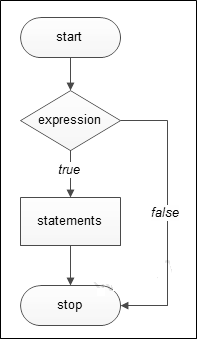

```python
Image(filename='ifstatments.png')
```

```python
# Syntax:
if expression:
    # excute your code
```

- If the logical condition is true, then the indented statement gets executed.
- If the logical condition is false, the indented statement is skipped

### Example-1

```python
a=15
if a>10:
    print("Pass")
```

```
Pass
```

### Example-2

### Output: Skipped

```python
a=9
if a>10:
    print("Pass")
```

### Example-3

```python
a=-5
if a<0:
    print("Fail")
```

```
Fail
```

### Example-4

```python
a = 15
if a > 10 and a<20:
    print("A+")
```

```
A+
```

# 6.2 if else Statements

### Alternative execution

- The if else structures can be recognized and understood using flowcharts.
- A second form of the if statement is alternative execution, in which there are two possibilities and the condition determines which one gets executed.
- Since the condition must either be true or false, exactly one of the alternatives will be executed.
- The alternatives are called branches, because they are branches in the flow of execution.

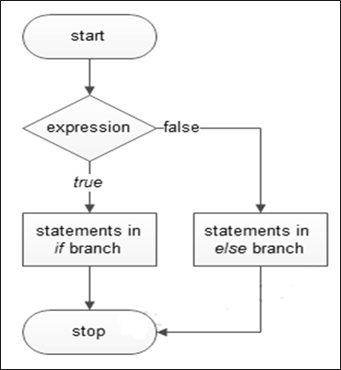

```python
Image(filename='ifelse.png')
```

```python
# Syntax:
if expression:
    # execute your code
else:
    # execute your code
```

### Example-1

```python
a = 12
if a > 10 and a<20:
    print("A+")
else:
    print("Fail")
```

```
A+
```

### Example-2

```python
a = 4
if a > 10 and a<20:
    print("A+")
else:
    print("Fail")
```

```
Fail
```

### Example-3

```python
a = 15; b = 20;
if a > b:
    print("a is greater")
else:
    print("b is greater")
```

```
b is greater
```

### Example-4

```python
a = 20; b = 15;
if a > b:
    print("a is greater")
else:
    print("b is greater")
```

```
a is greater
```

### Example-5

```python
x=25
if x%2 == 0:
    print('x is Even')
else:
    print('x is Odd')
```

```
x is Odd
```

### Example-6

```python
x=20
if x%2 == 0:
    print('x is Even')
else:
    print('x is Odd')
```

```
x is Even
```

- If the remainder when x is divided by 2 is 0, then we know that x is even, and the program displays a message to that effect.
- If the condition is false, the second set of statements is executed.

### Chained conditionals (elif Statements)

- Description:It also contains a Boolean expression. The if statement is followed by an optional else statement & if the expression results in FALSE, then else statement gets executed. It is also called alternative execution in which there are two possibilities of the condition determined in which any one of them will get executed.
- Sometimes there are more than two possibilities and we need more than two branches.
- One way to express a computation like that is a chained conditional.
- elif is an abbreviation of “else if.”
- Again, exactly one branch will be executed.
- There is no limit on the number of elif statements
- If there is an else clause, it has to be at the end, but there doesn’t have to be one.

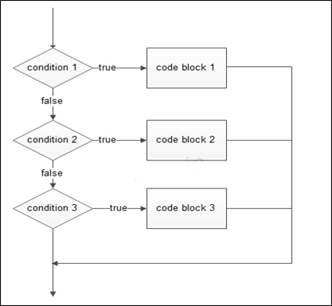

```python
Image(filename='elseif.png')
```

```python
Syntex:
if expression:
    # execute your code
elif expression:
    # execute your code
else:
    # execute your code
```

### Example-1

```python
a = 15;b = 15;
if a > b:
    print("a is greater")
elif a == b:
    print("both are equal")
else:
    print("b is greater")
```

```
both are equal
```

### Example-2

```python
choice ='a'
if choice == 'a':
    print('Bad guess')
elif choice == 'b':
    print('Good guess')
elif choice == 'c':
    print('Close, but not correct')
```

```
Bad guess
```

- Each condition is checked in order. If the first is false, the next is checked, and so on.
- If one of them is true, the corresponding branch executes, and the statement ends.
- Even if more than one condition is true, only the first true branch executes.

# 6.3 Nested Statements

- Description:We can implement if statement and or if-else statement inside another if or if - else statement. Here more than one if conditions are applied & there can be more than one if within elif.

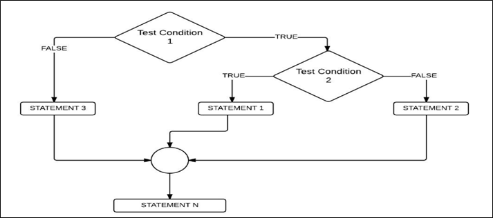

```python
Image(filename='nastedif.png')
```

```python
Syntex:
    if (Condition 1):
        # executes when condition1 is true
        if (Condition 2):
            #executes when condition2 is true
        #if Block is end here
    #if Block is end here
```

- If the Test Condition1 is FALSE then STATEMENT3 will be executed.
- If Test Condition1 is TRUE then it will check for the Test Condition2, if it is TRUE then STATEMENT1 will be executed or else STATEMENT2.

```python
age=int(input("Please enter your age: "))
if age<18:
    print("Your are Minor")
    print("Yor are not Eligible to Work")
else:
    if age >=18 and age <=60:
        print("You are Eligible to Work")
        print("Please fill your details and apply")
    else:
        print("You are too old to work as per Goverment rules")
        print("Please collect your pension!")
```

```
Please enter your age: 23
You are Eligible to Work
Please fill your details and apply
```

# Chapter 7: User Define Functions

```python
YouTubeVideo('BVfCWuca9nw',width=900, height=500)
```

[video not shown]

### Function

- Functions are reusable pieces of programs.
- They allow you to give a name to a block of statements, allowing you to run that block using the specified name anywhere in your program and any number of times. This is known as calling the function.

### Syntex

- Functions are defined using the def keyword.
- After this keyword comes an identifier name for the function
- Followed by a pair of parentheses which may enclose some names of variables.
- and by the final colon that ends the line.
- Next follows the block of statements that are part of this function.

```python
def say_hello():
    # block belonging to the function
    print('Hello Class')
    print('I am Umer Saeed')
    # End of function
```

```python
say_hello()
```

```
Hello Class
I am Umer Saeed
```

# 7.1 Function Parameters

- A function can take parameters, which are values you supply to the function so that the function can do something utilizing those values.
- These parameters are just like variables except that the values of these variables are defined when we call the function and are already assigned values when the function runs.
- Parameters are specified within the pair of parentheses in the function definition, separated by commas.
- When we call the function, we supply the values in the same way.
- Note the terminology used - the names given in the function definition are called parameters
- whereas the values you supply in the function call are called arguments.

### Example-1

```python
def umer_max(a, b):
    if a > b:
        print(a, 'is maximum')
    elif a == b:
        print(a, 'is equal to', b)
    else:
        print(b, 'is maximum')
```

```python
umer_max(6,4)
```

```
6 is maximum
```

```python
 a=16; b=4; umer_max(a, b)
```

```
16 is maximum
```

```python
 x=10; y=16; umer_max(x, y)
```

```
16 is maximum
```

```python
umer_max(a=8, b=4)
```

```
8 is maximum
```

# 7.2 Local Variables

- When you declare variables inside a function definition, they are not related in any way to other variables with the same names used outside the function - i.e. variable names are local to the function.
- This is called the scope of the variable.
- All variables have the scope of the block they are declared in starting from the point of definition of the name.

### Example-1

```python
x = 50
def func(x):
    print('x is', x)
    x = 2
    print('Changed local x to', x)
func(x)
```

```
x is 50
Changed local x to 2
```

### Example-2

```python
x = 50
def func(x):
    print('x is', x)
    x = 2
    print('Changed local x to', x)
func(x)
print('x is still', x)
```

```
x is 50
Changed local x to 2
x is still 50
```

- The first time that we print the value of the name x with the first line in the function's body, Python uses the value of the parameter declared in the main block, above the function definition.
- Next, we assign the value 2 to x. The name x is local to our function. So, when we change the value of x in the function, the x defined in the main block remains unaffected.
- With the last print statement, we display the value of x as defined in the main block, thereby confirming that it is actually unaffected by the local assignment within the previously called function

# 7.3 The global statement

- If you want to assign a value to a name defined at the top level of the program (i.e. not inside any kind of scope such as functions or classes), then you have to tell Python that the name is not local, but it is global.
- We do this using the global statement.
- It is impossible to assign a value to a variable defined outside a function without the global statement.
- You can use the values of such variables defined outside the function (assuming there is no variable with the same name within the function).
- However, this is not encouraged and should be avoided since it becomes unclear to the reader of the program as to where that variable's definition is.
- Using the global statement makes it amply clear that the variable is defined in an outermost block.

```python
x = 50
def func():
    global x
    print('x is', x)
    x = 2
    print('Changed global x to', x)
func()
print('Value of x is', x)
y=x+1
print(y)
```

```
x is 50
Changed global x to 2
Value of x is 2
3
```

- The global statement is used to declare that x is a global variable - hence, when we assign a value to x inside the function, that change is reflected when we use the value of x in the main block.
- You can specify more than one global variable using the same global statement e.g. global x, y, z.

# 7.4 Default Argument Values

### Example-1

```python
def say(message, times=2):
    print(message * times)
```

```python
say("Hello")
```

```
HelloHello
```

```python
say('Umer Saeed', 5)
```

```
Umer SaeedUmer SaeedUmer SaeedUmer SaeedUmer Saeed
```

### CAUTION:

- Only those parameters which are at the end of the parameter list can be given default argument values i.e. you cannot have a parameter with a default argument value preceding a parameter without a default argument value in the function's parameter list.
- This is because the values are assigned to the parameters by position. For example, def func(a, b=5) is valid, but def func(a=5, b) is not valid.

### Keyword Arguments

- If you have some functions with many parameters and you want to specify only some of them, then you can give values for such parameters by naming them - this is called keyword arguments - we use the name (keyword) instead of the position (which we have been using all along) to specify the arguments to the function.
- There are two advantages;
- 1- Using the function is easier since we do not need to worry about the order of the arguments.
- 2- we can give values to only those parameters to which we want to, provided that the other parameters have default argument values.

```python
def func(a, b=5, c=10):
    print('a is', a, 'and b is', b, 'and c is', c)
```

- The function named func has one parameter without a default argument value, followed by two parameters with default argument values.

```python
func(3, 7)
```

```
a is 3 and b is 7 and c is 10
```

- In the first usage, func(3, 7), the parameter a gets the value 3, the parameter b gets the value 7and c gets the default value of 10.

```python
func(25, c=24)
```

```
a is 25 and b is 5 and c is 24
```

- In the second usage func(25, c=24), the variable a gets the value of 25 due to the position of the argument. Then, the parameter c gets the value of 24 due to naming i.e. keyword arguments. The variable b gets the default value of 5.

```python
func(c=50, a=100)
```

```
a is 100 and b is 5 and c is 50
```

- In the third usage func(c=50, a=100), we use keyword arguments for all specified values. Notice that we are specifying the value for parameter c before that for a even though a is defined before c in the function definition.

# 7.5 The return statement

- The return statement is used to return from a function i.e. break out of the function.
- We can optionally return a value from the function as well.

### Example-1

```python
def maximum(x, y):
    if x > y:
        return x
    elif x == y:
        return 'The numbers are equal'
    else:
        return y
```

```python
maximum(7, 4)
```

```
7
```

```python
maximum(8,8)
```

```
'The numbers are equal'
```

```python
maximum(4,7)
```

```
7
```

### Example-2

```python
def basicArithmetic(x, y):
    # Do the calulations and put each result into a variable
    sum1 = x + y
    difference = x - y
    product = x * y
    quotient = x / y
    # Return each variable
    return sum1, difference, product, quotient
```

```python
basicArithmetic(10, 2)
```

```
(12, 8, 20, 5.0)
```

# 7.6 DocStrings

- Python has a nifty feature called documentation strings, usually referred to by its shorter name docstrings.
- DocStrings are an important tool that you should make use of since it helps to document the program better and makes it easier to understand.
- Amazingly, we can even get the docstring back from, say a function, when the program is actually running!

```python
def print_max(x, y):
    '''Prints the maximum of two numbers.
    The two values must be integers.'''
    # convert to integers, if possible
    x = int(x)
    y = int(y)
    if x > y:
        print(x, 'is maximum')
    else:
        print(y, 'is maximum')
```

```python
print_max(3, 5)
print(print_max.__doc__)
```

```
5 is maximum
Prints the maximum of two numbers.
    The two values must be integers.
```

# Chapter 8: Python Loops

- Python has two primitive loop commands:
- 1- while loop
- 2- for loop

# 8.1 while loop

```python
YouTubeVideo('HZARImviDxg',width=900, height=500)
```

[video not shown]

- Description:The loop gets repeated until the certain Boolean condition is met.
- Computers are often used to automate repetitive tasks.
- The while statement allows you to repeatedly execute a block of statements as long as a condition is true.
- Repeating identical or similar tasks without making errors is something that computers do well and people do poorly.
- The graphical representation of the logic behind while looping is shown below

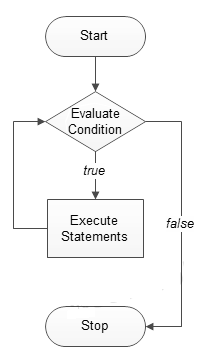

```python
Image(filename='whileloop.png')
```

```python
Syntax:
while expression:
    # execute your code
You can almost read the while statement as if it were English
```

### Example-1

```python
i = 1
while i < 6:
    print(i)
    i += 1
```

```
1
2
3
4
5
```

- Set a counter to 1
- Enter a while loop that keeps repeating while the number is less than 6
- Each time it repeats, print the counter value to the screen
- Increment the counter by 1

### Example-2

```python
n = 5
while n > 0:
    print(n)
    n = n - 1
    print('Blastoff!')
```

```
5
Blastoff!
4
Blastoff!
3
Blastoff!
2
Blastoff!
1
Blastoff!
```

```python
count =1
while count < 6 :
    print (count)
    count+=1
```

```
1
2
3
4
5
```

### A while Loop with else

- Python lets you add an else part to your loops. This is similar to using else with an if statement.
- It lets you specify what to do when/if the loop condition becomes false.

```python
counter = 1
while (counter <10):
        print (counter)
        counter = counter +1
else:
        print("The loop has successfully completed!")
```

```
1
2
3
4
5
6
7
8
9
The loop has successfully completed!
```

### Positioning the Counter Increment

- A common mistake that new programmers make is putting the counter increment in the wrong place. Of course, you can put it anywhere within your loop, however, bear in mind that its position can affect the output.
- Here's what happens if we modify the previous example, so that the counter increments before we print its value:

```python
counter = 1
while (counter < 10):
    counter = counter +1
    #We moved this line
    print (counter)
```

```
2
3
4
5
6
7
8
9
10
```

### Example

```python
number = 23
running = True
while running:
    guess = int(input('Enter an integer : '))
    if guess == number:
        print('Congratulations, you guessed it.')
        # this causes the while loop to stop
        running = False
    elif guess < number:
        print('No, it is a little higherthan that.')
    else:
        print('No, it is a little lower than that.')
else:
    print('The while loop is over.')
        # Do anything else you want to do here
print('Done')
```

```
Enter an integer : 23
Congratulations, you guessed it.
The while loop is over.
Done
```

### The break Statement

- With the break statement we can stop the loop even if the while condition is true:

```python
i = 1
while i < 6:
  print(i)
  if i == 3:
    break
  i += 1
```

```
1
2
3
```

### The continue Statement

- With the continue statement we can stop the current iteration, and continue with the next:

```python
i = 0
while i < 6:
  i += 1
  if i == 3:
    continue
  print(i)
```

```
1
2
4
5
6
```

# 8.2 for loop

```python
YouTubeVideo('0ZvaDa8eT5s',width=900, height=500)
```

[video not shown]

- Description:This is traditionally used when programmers have a piece of code and wanted to repeat that 'n' number of times.
- A for loop is used for iterating over a sequence (that is either a list, a tuple, a dictionary, a set, or a string).
- The graphical representation of the logic behind for looping is shown below:

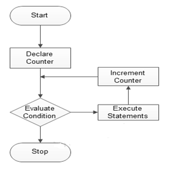

```python
Image(filename='forloop.png')
```

```python
Syntax:
for iterating_var in sequence:
    # execute your code
```

### Example-1::Looping Through a List

```python
bro = ["Umer Saeed", "Ali Saeed", "Ahmed Abdullah Saeed"]
for x in bro:
  print(x)
```

```
Umer Saeed
Ali Saeed
Ahmed Abdullah Saeed
```

### Example-2

```python
for x in "Umer SAEED":
  print(x)
```

```
U
m
e
r

S
A
E
E
D
```

### Example-3::break statment

```python
bro = ["Umer Saeed", "Ali Saeed", "Ahmed Abdullah Saeed"]
for x in bro:
  print(x)
  if x == "Ali Saeed":
    break
```

```
Umer Saeed
Ali Saeed
```

### Example-4::break statment

```python
for x in "Umer SAEED":
  print(x)
  if x == "e":
    break
```

```
U
m
e
```

### Example-5::The continue Statement

- With the continue statement we can stop the current iteration of the loop, and continue with the next:

```python
fruits = ["apple", "banana", "cherry"]
for x in fruits:
  if x == "banana":
    continue
  print(x)
```

```
apple
cherry
```

### Example-6::The range() Function

```python
for x in range(6):
  print(x)
```

```
0
1
2
3
4
5
```

### Example-7::The range() Function

```python
for x in range(2, 6):
  print(x)
```

```
2
3
4
5
```

### Example-8::The range() Function

```python
for x in range(2, 15, 3):
  print(x)
```

```
2
5
8
11
14
```

### Example-9::A for Loop with else

- Python lets you add an else part to your loops.
- This is similar to using else with an if statement.
- It lets you specify what to do when the loop has finished.

```python
for x in range(6):
  print(x)
else:
  print("Finally finished!")
```

```
0
1
2
3
4
5
Finally finished!
```

### Nested Loops

- A nested loop is a loop inside a loop.
- The "inner loop" will be executed one time for each iteration of the "outer loop":
- Description: Programmers can use one loop inside another; i.e. they can use for loop inside while or vice - versa or for loop inside for loop or while inside while

```python
Syntax:
for iterating_var in sequence:
     for iterating_var in sequence:
            # execute your code
                # execute your code
```

### Example-1

```python
adj = ["red", "big", "tasty"]
fruits = ["apple", "banana", "cherry"]

for x in adj:
  for y in fruits:
    print(x, y)
```

```
red apple
red banana
red cherry
big apple
big banana
big cherry
tasty apple
tasty banana
tasty cherry
```

### Example-2

```python
for g in range(1,6):
    for k in range(1, 3):
        print ("%d * %d = %d" % ( g, k, g*k))
```

```
1 * 1 = 1
1 * 2 = 2
2 * 1 = 2
2 * 2 = 4
3 * 1 = 3
3 * 2 = 6
4 * 1 = 4
4 * 2 = 8
5 * 1 = 5
5 * 2 = 10
```

### Pass Statment

- It is used in Python to when a statement is required syntactically and the programmer does not want to execute any code block or command.

```python
for letter in 'Umer Saeed':
    if letter == ' ':
        print ('Pass block')
        pass
    print ('Current letter is:', letter)
```

```
Current letter is: U
Current letter is: m
Current letter is: e
Current letter is: r
Pass block
Current letter is:
Current letter is: S
Current letter is: a
Current letter is: e
Current letter is: e
Current letter is: d
```

# Chapter 9: Python File Handling

# 9.1 Introduction

- All programs need the input to process and output to display data.
- And everything needs a file as name storage compartments on computers that are managed by OS.
- Though variables provide us a way to store data while the program runs, if we want out data to persist even after the termination of the program, we have to save it to a file.
- There are always two parts of a file in the computer system;
- 1- the filename
- 2- its extension
- Also, the files have two key properties -
- 1- its name
- 2- the location or path, which specifies the location where the file exists
- The file name has two parts and they are separated by a dot (.) or period

[figure not shown]

```python
from IPython.display import Image
Image(filename='File_and_path.png')
```

```python
from IPython.display import YouTubeVideo
YouTubeVideo('tJxcKyFMTGo',width=900, height=500)
```

[video not shown]

# 9.2 Import Library for Path and File Management

```python
import os
```

# 9.3 Get working Directory

```python
os.getcwd()
```

```
'C:\\Users\\uwx161178.CHINA\\UmerSaeed\\Python_for_Data_Science_Volume-1_V0'
```

# 9.4 Change working Path

```python
os.chdir('E:\\Python')
```

```python
os.getcwd()
```

```
'E:\\Python'
```

# 9.5 List Current Directory

```python
os.listdir(os.curdir)
```

```
['AbdullahSaeed',
 'AhmedAbdullahSaeed',
 'AliSaeed',
 'Hassan',
 'Hello.txt',
 'Hello1.txt',
 'Jamal',
 'Khalid',
 'Rizwan',
 'Student_Name.txt']
```

# 9.6 Make a new Directory in Current Directory

### Method-1

```python
os.mkdir('MMAlam')
```

```python
os.listdir(os.curdir)
```

```
['AbdullahSaeed',
 'AhmedAbdullahSaeed',
 'AliSaeed',
 'Hassan',
 'Hello.txt',
 'Hello1.txt',
 'Jamal',
 'Khalid',
 'MMAlam',
 'Rizwan',
 'Student_Name.txt']
```

```python
os.listdir(os.curdir)
```

```
['AbdullahSaeed',
 'AhmedAbdullahSaeed',
 'AliSaeed',
 'Hassan',
 'Hello.txt',
 'Hello1.txt',
 'Jamal',
 'Khalid',
 'MMAlam',
 'Rizwan',
 'Student_Name.txt']
```

```python
os.mkdir('Adnan/Mansoor')
```

```
---------------------------------------------------------------------------
FileNotFoundError                         Traceback (most recent call last)
<ipython-input-524-66018a6399a5> in <module>
----> 1 os.mkdir('Adnan/Mansoor')

FileNotFoundError: [WinError 3] The system cannot find the path specified: 'Adnan/Mansoor'
```

### Method-2

```python
os.makedirs('Tariq')
```

```python
os.listdir(os.curdir)
```

```
['AbdullahSaeed',
 'AhmedAbdullahSaeed',
 'AliSaeed',
 'Hassan',
 'Hello.txt',
 'Hello1.txt',
 'Jamal',
 'Khalid',
 'MMAlam',
 'Rizwan',
 'Student_Name.txt',
 'Tariq']
```

```python
os.makedirs('Bilal/Ijlal')
```

```python
os.listdir(os.curdir)
```

```
['AbdullahSaeed',
 'AhmedAbdullahSaeed',
 'AliSaeed',
 'Bilal',
 'Hassan',
 'Hello.txt',
 'Hello1.txt',
 'Jamal',
 'Khalid',
 'MMAlam',
 'Rizwan',
 'Student_Name.txt',
 'Tariq']
```

# 9.7 Delete Directory in Current Directory

### Method-1

```python
os.rmdir('Rizwan')
```

```python
os.listdir(os.curdir)
```

```
['AbdullahSaeed',
 'AhmedAbdullahSaeed',
 'AliSaeed',
 'Bilal',
 'Hassan',
 'Hello.txt',
 'Hello1.txt',
 'Jamal',
 'Khalid',
 'MMAlam',
 'Student_Name.txt',
 'Tariq']
```

### Method-2

```python
os.removedirs('Bilal/Ijlal')
```

```python
os.listdir(os.curdir)
```

```
['AbdullahSaeed',
 'AhmedAbdullahSaeed',
 'AliSaeed',
 'Hassan',
 'Hello.txt',
 'Hello1.txt',
 'Jamal',
 'Khalid',
 'MMAlam',
 'Student_Name.txt',
 'Tariq']
```

# 9.8 Rename Directory in Current Directory

```python
os.rename('AliSaeed','UmerSaeed')
```

```python
os.listdir(os.curdir)
```

```
['AbdullahSaeed',
 'AhmedAbdullahSaeed',
 'Hassan',
 'Hello.txt',
 'Hello1.txt',
 'Jamal',
 'Khalid',
 'MMAlam',
 'Student_Name.txt',
 'Tariq',
 'UmerSaeed']
```

# 9.9 Rename File

```python
os.listdir(os.curdir)
```

```
['AbdullahSaeed',
 'AhmedAbdullahSaeed',
 'Hassan',
 'Hello.txt',
 'Hello1.txt',
 'Jamal',
 'Khalid',
 'MMAlam',
 'Student_Name.txt',
 'Tariq',
 'UmerSaeed']
```

```python
os.rename('Student_Name.txt','Student_ID.txt')
```

```python
os.listdir(os.curdir)
```

```
['AbdullahSaeed',
 'AhmedAbdullahSaeed',
 'Hassan',
 'Hello.txt',
 'Hello1.txt',
 'Jamal',
 'Khalid',
 'MMAlam',
 'Student_ID.txt',
 'Tariq',
 'UmerSaeed']
```

# 9.10 stat in os

```python
os.stat('Student_ID.txt')
```

```
os.stat_result(st_mode=33206, st_ino=10696049115103874, st_dev=308057831, st_nlink=1, st_uid=0, st_gid=0, st_size=37, st_atime=1567263508, st_mtime=1543953106, st_ctime=1543938112)
```

### Size of the File

```python
os.stat('Student_ID.txt').st_size
```

```
37
```

### Time of the Last Modification

```python
os.stat('Student_ID.txt').st_mtime
```

```
1543953106.066651
```

#### Time Format

```python
from datetime import datetime
```

```python
ctimc=os.stat('Student_ID.txt').st_mtime
```

```python
datetime.fromtimestamp(ctimc)
```

```
datetime.datetime(2018, 12, 5, 0, 51, 46, 66651)
```

# 9.11 walk

```python
#for dirpath, dirnames, filenames in os.walk('E:\Python'):
for dirpath, dirnames, filenames in os.walk(os.getcwd()):
    print('Current Path:', dirpath)
    print('Directories:', dirnames)
    print('Files', filenames)
    print()
```

```
Current Path: E:\Python
Directories: ['AbdullahSaeed', 'AhmedAbdullahSaeed', 'Hassan', 'Jamal', 'Khalid', 'MMAlam', 'Tariq', 'UmerSaeed']
Files ['Hello.txt', 'Hello1.txt', 'Student_ID.txt']

Current Path: E:\Python\AbdullahSaeed
Directories: []
Files []

Current Path: E:\Python\AhmedAbdullahSaeed
Directories: []
Files []

Current Path: E:\Python\Hassan
Directories: []
Files []

Current Path: E:\Python\Jamal
Directories: []
Files []

Current Path: E:\Python\Khalid
Directories: []
Files []

Current Path: E:\Python\MMAlam
Directories: []
Files []

Current Path: E:\Python\Tariq
Directories: []
Files []

Current Path: E:\Python\UmerSaeed
Directories: []
Files []
```

# 9.12 Exists Path

```python
print(os.path.exists('E/Ali'))
```

```
False
```

```python
print(os.path.exists('E:\\Python'))
```

```
True
```

# 9.13 isdir

```python
os.listdir(os.curdir)
```

```
['AbdullahSaeed',
 'AhmedAbdullahSaeed',
 'Hassan',
 'Hello.txt',
 'Hello1.txt',
 'Jamal',
 'Khalid',
 'MMAlam',
 'Student_ID.txt',
 'Tariq',
 'UmerSaeed']
```

```python
print(os.path.isdir('Rizwan'))
```

```
False
```

# 9.14 isfile

```python
print(os.path.isfile('Student_Name.txt'))
```

```
False
```

# 9.15 Python script to rename a folder if the folder name similar to line in a text file to that exact line

- [More information](https://stackoverflow.com/questions/31435984/python-rename-files-in-subfolders-based-on-subfolder-and-file-name)

```python
import os
fld ='D:\MS DS\CGID'

for root, subdirs, files in os.walk(fld):
    for name in files:
        curr_fld = os.path.basename(root)
        oldname = os.path.join(fld,curr_fld, name)
        splt_name =  name.split('.')
        myname = '_'.join([splt_name[0], curr_fld + '.' + splt_name[1]])
        newname = os.path.join(fld,curr_fld, myname)
        os.rename(oldname,newname)
```

```python
import pandas as pd
pd.Series(os.listdir('D:\MS DS\CGID'))
```

```
0    Ahmd
1     Ali
2    Umer
dtype: object
```

# 9.16 Available Options in os

```python
dir(os)
```

[output not shown]

[output cut: 95 more lines]

[output not shown]

```python
dir(os.path)
```

```
['__all__',
 '__builtins__',
 '__cached__',
 '__doc__',
 '__file__',
 '__loader__',
 '__name__',
 '__package__',
 '__spec__',
 '_abspath_fallback',
 '_get_bothseps',
 '_getfinalpathname',
 '_getfullpathname',
 '_getvolumepathname',
 'abspath',
 'altsep',
 'basename',
 'commonpath',
 'commonprefix',
 'curdir',
 'defpath',
 'devnull',
 'dirname',
 'exists',
 'expanduser',
 'expandvars',
 'extsep',
 'genericpath',
 'getatime',
 'getctime',
 'getmtime',
 'getsize',
 'isabs',
 'isdir',
 'isfile',
 'islink',
 'ismount',
 'join',
 'lexists',
 'normcase',
 'normpath',
 'os',
 'pardir',
 'pathsep',
 'realpath',
 'relpath',
 'samefile',
 'sameopenfile',
 'samestat',
 'sep',
 'split',
 'splitdrive',
 'splitext',
 'stat',
 'supports_unicode_filenames',
 'sys']
```

# Chapter 10: Python Math Library

```python
from IPython.display import YouTubeVideo
YouTubeVideo('BVMv4xHOe3o',width=900, height=500)
```

[video not shown]

```python
YouTubeVideo('03s-YxzRhlg',width=900, height=500)
```

[video not shown]

```python
YouTubeVideo('L_Ftijam7RE',width=900, height=500)
```

[video not shown]

```python
YouTubeVideo('CMMFH89kIlQ',width=900, height=500)
```

[video not shown]

```python
YouTubeVideo('eeQPb6rDA4E',width=900, height=500)
```

[video not shown]

```python
YouTubeVideo('BqPjbAv5UNo',width=900, height=500)
```

[video not shown]

```python
YouTubeVideo('pD5V61OV-GU',width=900, height=500)
```

[video not shown]

```python
YouTubeVideo('sJBjWXdVhIM',width=900, height=500)
```

[video not shown]

```python
YouTubeVideo('gWqfs58dFyM',width=900, height=500)
```

[video not shown]

# 10.1 Import Library for Math Functions

```python
import math
```

# 10.2 Power and Logarithmic Functions

### math.e

```python
math.e
```

```
2.718281828459045
```

### math.exp(x)

- Return e raised to the power x

```python
math.exp(2)
```

```
7.38905609893065
```

- This is usually more accurate than math.e**x or pow(math.e, x).

```python
math.e**2
```

```
7.3890560989306495
```

```python
pow(math.e,2)
```

```
7.3890560989306495
```

### expm1:math.expm1(x)

- 1- Return e raised to the power x, minus 1
- 2- Here e is the base of natural logarithms
- 3- For small floats x, the subtraction in exp(x) - 1 can result in a significant loss of precision; the expm1() function provides a way to compute this quantity to full precision:

```python
math.expm1(1e-5)
```

```
1.0000050000166667e-05
```

```python
math.exp(1e-5) - 1
```

```
1.0000050000069649e-05
```

### log:math.log(x,[base])

- 1- With one argument, return the natural logarithm of x (to base e).
- 2- With two arguments, return the logarithm of x to the given base, calculated as log(x)/log(base).

```python
math.log(8,math.e)
```

```
2.0794415416798357
```

```python
math.log(8)
```

```
2.0794415416798357
```

```python
math.log(8)/math.log(math.e)
```

```
2.0794415416798357
```

### log1p:math.log1p(x)

- Return the natural logarithm of 1+x(base e)

```python
math.log(8)
```

```
2.0794415416798357
```

```python
math.log1p(7)
```

```
2.0794415416798357
```

### log2:math.log2(x)

- Return the base 2 logarithm of x
- This is usually more accurate than log(x, 2).

```python
math.log2(10)
```

```
3.321928094887362
```

```python
math.log(10,2)
```

```
3.3219280948873626
```

### log10:math.log10(x)

- Return the base 10 logarithm of x
- This is usually more accurate than log(x, 10)

```python
math.log10(10)
```

```
1.0
```

```python
math.log(10,10)
```

```
1.0
```

### pow:math.pow(x,y)

- Return x raised to the power y

```python
math.pow(0, 0)
```

```
1.0
```

```python
math.pow(2, 0)
```

```
1.0
```

```python
math.pow(float('nan'), 0)
```

```
1.0
```

```python
math.pow(float('inf'), 0)
```

```
1.0
```

```python
math.pow(float('-inf'), 0)
```

```
1.0
```

```python
math.pow(2, -2)
```

```
0.25
```

```python
math.pow(-2, 2)
```

```
4.0
```

```python
math.pow(2.2, -2)
```

```
0.20661157024793386
```

```python
math.pow(2.2, -2.2)
```

```
0.1764696816352779
```

```python
math.pow(-2, 2.1)
```

```
---------------------------------------------------------------------------
ValueError                                Traceback (most recent call last)
<ipython-input-588-4f22646cfbae> in <module>
----> 1 math.pow(-2, 2.1)

ValueError: math domain error
```

```python
math.pow(2,float('nan'))
```

```
nan
```

```python
math.pow(2,float('inf'))
```

```
inf
```

```python
math.pow(2,float('-inf'))
```

```
0.0
```

# 10.3 Trigonometric Functions

- [More information](https://github.com/umersaeed81h/pic/blob/master/INVERSE_TRIGONOMETRIC_FUNCTIONS.pdf)

### Angular conversion

- math.degrees(x): Convert angle x from radians to degrees.
- math.radians(x): Convert angle x from degrees to radians.

```python
math.degrees(3.141592653589793)
```

```
180.0
```

```python
math.radians(180)
```

```
3.141592653589793
```

### Return the cosine of x radians

```python
round(math.cos(math.radians(0)),2)
```

```
1.0
```

```python
round(math.cos(math.radians(30)),2)
```

```
0.87
```

```python
round(math.cos(math.radians(60)),2)
```

```
0.5
```

```python
round(math.cos(math.radians(90)),2)
```

```
0.0
```

```python
round(math.cos(math.radians(120)),2)
```

```
-0.5
```

```python
round(math.cos(math.radians(150)),2)
```

```
-0.87
```

```python
round(math.cos(math.radians(180)),2)
```

```
-1.0
```

```python
round(math.cos(math.radians(210)),2)
```

```
-0.87
```

```python
round(math.cos(math.radians(240)),2)
```

```
-0.5
```

```python
round(math.cos(math.radians(270)),2)
```

```
-0.0
```

```python
round(math.cos(math.radians(300)),2)
```

```
0.5
```

```python
round(math.cos(math.radians(330)),2)
```

```
0.87
```

```python
round(math.cos(math.radians(360)),2)
```

```
1.0
```

```python
round(math.cos(0*math.pi),2)
```

```
1.0
```

```python
round(math.cos((1/6)*math.pi),2)
```

```
0.87
```

```python
round(math.cos((1/3)*math.pi),2)
```

```
0.5
```

```python
round(math.cos((1/2)*math.pi),2)
```

```
0.0
```

```python
round(math.cos((2/3)*math.pi),2)
```

```
-0.5
```

```python
round(math.cos((5/6)*math.pi),2)
```

```
-0.87
```

```python
round(math.cos(math.pi),2)
```

```
-1.0
```

```python
round(math.cos((7/6)*math.pi),2)
```

```
-0.87
```

```python
round(math.cos((4/3)*math.pi),2)
```

```
-0.5
```

```python
round(math.cos((3/2)*math.pi),2)
```

```
-0.0
```

```python
round(math.cos((5/3)*math.pi),2)
```

```
0.5
```

```python
round(math.cos((11/6)*math.pi),2)
```

```
0.87
```

```python
round(math.cos(2*math.pi),2)
```

```
1.0
```

### Return the sine of x radians

```python
round(math.sin(math.radians(0)),2)
```

```
0.0
```

```python
round(math.sin(math.radians(30)),2)
```

```
0.5
```

```python
round(math.sin(math.radians(60)),2)
```

```
0.87
```

```python
round(math.sin(math.radians(90)),2)
```

```
1.0
```

```python
round(math.sin(math.radians(120)),2)
```

```
0.87
```

```python
round(math.sin(math.radians(150)),2)
```

```
0.5
```

```python
round(math.sin(math.radians(180)),2)
```

```
0.0
```

```python
round(math.sin(math.radians(210)),2)
```

```
-0.5
```

```python
round(math.sin(math.radians(240)),2)
```

```
-0.87
```

```python
round(math.sin(math.radians(270)),2)
```

```
-1.0
```

```python
round(math.sin(math.radians(300)),2)
```

```
-0.87
```

```python
round(math.sin(math.radians(330)),2)
```

```
-0.5
```

```python
round(math.sin(math.radians(360)),2)
```

```
-0.0
```

```python
round(math.sin(0*math.pi),2)
```

```
0.0
```

```python
round(math.sin((1/6)*math.pi),2)
```

```
0.5
```

```python
round(math.sin((1/3)*math.pi),2)
```

```
0.87
```

```python
round(math.sin((1/2)*math.pi),2)
```

```
1.0
```

```python
round(math.sin((2/3)*math.pi),2)
```

```
0.87
```

```python
round(math.sin((5/6)*math.pi),2)
```

```
0.5
```

```python
round(math.sin(math.pi),2)
```

```
0.0
```

```python
round(math.sin((7/6)*math.pi),2)
```

```
-0.5
```

```python
round(math.sin((4/3)*math.pi),2)
```

```
-0.87
```

```python
round(math.sin((3/2)*math.pi),2)
```

```
-1.0
```

```python
round(math.sin((5/3)*math.pi),2)
```

```
-0.87
```

```python
round(math.sin((11/6)*math.pi),2)
```

```
-0.5
```

```python
round(math.sin(2*math.pi),2)
```

```
-0.0
```

### Return the tangent of x radians

```python
round(math.tan(math.radians(0)),2)
```

```
0.0
```

```python
round(math.tan(math.radians(30)),2)
```

```
0.58
```

```python
round(math.tan(math.radians(60)),2)
```

```
1.73
```

```python
round(math.tan(math.radians(90)),2)
```

```
1.633123935319537e+16
```

```python
round(math.tan(math.radians(120)),2)
```

```
-1.73
```

```python
round(math.tan(math.radians(150)),2)
```

```
-0.58
```

```python
round(math.tan(math.radians(180)),2)
```

```
-0.0
```

```python
round(math.tan(math.radians(210)),2)
```

```
0.58
```

```python
round(math.tan(math.radians(240)),2)
```

```
1.73
```

```python
round(math.tan(math.radians(270)),2)
```

```
5443746451065123.0
```

```python
round(math.tan(math.radians(300)),2)
```

```
-1.73
```

```python
round(math.tan(math.radians(330)),2)
```

```
-0.58
```

```python
round(math.tan(math.radians(360)),2)
```

```
-0.0
```

```python
round(math.tan(0*math.pi),2)
```

```
0.0
```

```python
round(math.tan((1/6)*math.pi),2)
```

```
0.58
```

```python
round(math.tan((1/3)*math.pi),2)
```

```
1.73
```

```python
round(math.tan((1/2)*math.pi),2)
```

```
1.633123935319537e+16
```

```python
round(math.tan((2/3)*math.pi),2)
```

```
-1.73
```

```python
round(math.tan((5/6)*math.pi),2)
```

```
-0.58
```

```python
round(math.tan(math.pi),2)
```

```
-0.0
```

```python
round(math.tan((7/6)*math.pi),2)
```

```
0.58
```

```python
round(math.tan((4/3)*math.pi),2)
```

```
1.73
```

```python
round(math.tan((3/2)*math.pi),2)
```

```
5443746451065123.0
```

```python
round(math.tan((5/3)*math.pi),2)
```

```
-1.73
```

```python
round(math.tan((11/6)*math.pi),2)
```

```
-0.58
```

```python
round(math.tan(2*math.pi),2)
```

```
-0.0
```

### Return the arc cosine of x radians

```python
round(math.degrees(math.acos(1)),2)
```

```
0.0
```

```python
round(math.degrees(math.acos(0)),2)
```

```
90.0
```

```python
round(math.degrees(math.acos(0.8660254037844387)),2)
```

```
30.0
```

```python
round(math.degrees(math.acos(0.5)),2)
```

```
60.0
```

```python
round(math.degrees(math.acos(-0.5)),2)
```

```
120.0
```

```python
round(math.degrees(math.acos(-0.8660254037844387)),2)
```

```
150.0
```

```python
round(math.degrees(math.acos(-1)),2)
```

```
180.0
```

```python
math.acos(1)
```

```
0.0
```

```python
math.acos(0)
```

```
1.5707963267948966
```

```python
math.acos(0.8660254037844387)
```

```
0.5235987755982987
```

```python
math.acos(0.5)
```

```
1.0471975511965979
```

```python
math.acos(-0.5)
```

```
2.0943951023931957
```

```python
math.acos(-0.8660254037844387)
```

```
2.6179938779914944
```

```python
math.acos(-1)
```

```
3.141592653589793
```

# 10.4 Number-theoretic and representation functions

### sqrt:math.sqrt(x)

```python
math.sqrt(25)
```

```
5.0
```

```python
math.sqrt(25.5)
```

```
5.049752469181039
```

```python
math.sqrt(-25)
```

```
---------------------------------------------------------------------------
ValueError                                Traceback (most recent call last)
<ipython-input-688-d80dea1ee982> in <module>
----> 1 math.sqrt(-25)

ValueError: math domain error
```

### Ceiling:(math.ceil(x))

- Return the ceiling of x, the smallest integer greater than or equal to x

```python
math.ceil(4.0)
```

```
4
```

```python
math.ceil(4.1)
```

```
5
```

```python
math.ceil(4.9)
```

```
5
```

### floor:math.floor(x)

- Return the floor of x, the largest integer less than or equal to x.

```python
math.floor(4.0)
```

```
4
```

```python
math.floor(4.1)
```

```
4
```

```python
math.floor(4.9)
```

```
4
```

### trunc:math.trunc(x)

- Real value x is truncated to an Integer and returned.

```python
math.trunc(4.0)
```

```
4
```

```python
math.trunc(4.1)
```

```
4
```

```python
math.trunc(4.9)
```

```
4
```

### Copy Sign :math.copysign(x,y)

- Return a float with the magnitude (absolute value) of x but the sign of y.

```python
math.copysign(5,6)
```

```
5.0
```

```python
math.copysign(5,-6)
```

```
-5.0
```

```python
math.copysign(5,0)
```

```
5.0
```

```python
math.copysign(5,-0)
```

```
5.0
```

```python
math.copysign(5,-0.0)
```

```
-5.0
```

### fabs:math.fabs(x)

- Return the absolute value of x

```python
math.fabs(5)
```

```
5.0
```

```python
math.fabs(-5)
```

```
5.0
```

```python
math.fabs(5.0)
```

```
5.0
```

```python
math.fabs(-5.0)
```

```
5.0
```

### factorial:math.factorial(x)

- Return x factorial. Raise ValueError if x is not integral or is negative.

```python
math.factorial(5)
```

```
120
```

```python
math.factorial(5.0)
```

```
120
```

```python
math.factorial(-5)
```

```
---------------------------------------------------------------------------
ValueError                                Traceback (most recent call last)
<ipython-input-709-a46d876612ec> in <module>
----> 1 math.factorial(-5)

ValueError: factorial() not defined for negative values
```

```python
math.factorial(5.8)
```

```
---------------------------------------------------------------------------
ValueError                                Traceback (most recent call last)
<ipython-input-710-2cfdd54fae77> in <module>
----> 1 math.factorial(5.8)

ValueError: factorial() only accepts integral values
```

### fmod:math.fmod(x,y)

- Function fmod() is generally preferred when working with floats, while Python’s x%y is preferred when working with integers.

```python
math.fmod(10,6)
```

```
4.0
```

```python
10%6
```

```
4
```

```python
math.fmod(-1e-100, 1e100)
```

```
-1e-100
```

```python
-1e-100%1e100
```

```
1e+100
```

### fsum:math.fsum(iterable)

- 1- Return an accurate floating point sum of values in the iterable.
- 2- Avoids loss of precision by tracking multiple intermediate partial sums.

```python
sum([.1,.2,.3])
```

```
0.6000000000000001
```

```python
math.fsum([.1,0.2,0.3])
```

```
0.6
```

### GCD/HCF

### Example-1

- Find out GCD of 12 and 14.
- Step-1: To find out the divisor of these number that is the number which will divide this number completely.
  - For 12: 1,2,3,4,6,12
  - For 14: 1,2,7,14
- Step-2: To find out the common divisor.
- For 12 and 14 common divisor are 1,2.
- Step-3: To find out the greatest number in step-2.
- So the GCD of 12 and 14 is 2 because it is the greatest number in step-2

### Example-2.(Euclid's Algorithm For GCD)

- Find out GCD of 64 and 48 using Euclid’s Algorithm
- Step-1: To find out the bigger number, so here 64 is greater than 48.
- Step-2: 64 = 48 * x + reminder
  - 64= 48*1+16
- Step-3: 48=16*x + reminder
  - 48=16*3+0
- Step-4: 16= 0*x +reminder
- So the GCD of 64 and 48 is 16

### gcd:math.gcd(a,b)

- Return the greatest common divisor of the integers a and b.
- If either a or b is nonzero, then the value of gcd(a,b) is the largest positive integer that divides both a and b.

```python
math.gcd(0,0)
```

```
0
```

```python
math.gcd(12,14)
```

```
2
```

```python
math.gcd(64,48)
```

```
16
```

### isclose

```
                    abs(a-b)<=max(rel_tol * max(abs(a),abs(b)), abs_tol)
```

- Return True if the values a and b are close to each other and False otherwise.
- Whether or not two values are considered close is determined according to given absolute and relative tolerances.
- rel_tol is the relative tolerance – it is the maximum allowed difference between a and b, relative to the larger absolute value of a and b.
- For example, to set a tolerance of 5%, pass rel_tol=0.05.
- For example, to set a tolerance of 5%, pass rel_tol=0.05.
- The default tolerance is 1e-09, which assures that the two values are the same within about 9 decimal digits.
- rel_tol must be greater than zero.
- abs_tol is the minimum absolute tolerance – useful for comparisons near zero. abs_tol must be at least zero
- if no errors occur, the result will be:

  ```
                    abs(a-b)<=max(rel_tol * max(abs(a),abs(b)), abs_tol)
  ```

```python
math.isclose(50,49,rel_tol=0.05, abs_tol=0)
```

```
True
```

```python
math.isclose(50,49,rel_tol=1e-09, abs_tol=0)
```

```
False
```

### Solution Example-1

```
                            abs(a-b)<=max(rel_tol * max(abs(a),abs(b)), abs_tol)
                                abs(50-49)<=max(0.05*max(abs(50),abs(49)),0)
                                  abs(1) <= max(0.05*max(50,49),0)
                                   1<=max(0.05 * 50,0)
                                    1<=max(2.5,0)
                                    1<=2.5
                                    True
```

### Solution Example-2

[output not shown]

### isfinite:math.isfinite(x)

- Return True if x is neither an infinity nor a NaN, and False otherwise.

```python
math.isfinite(2)
```

```
True
```

```python
math.isfinite(0)
```

```
True
```

```python
math.isfinite(-2)
```

```
True
```

```python
math.isfinite (float('nan'))
```

```
False
```

```python
math.isfinite(float('inf'))
```

```
False
```

```python
math.isfinite(float('-inf'))
```

```
False
```

### isinf:math.isinf(x)

- Return True if x is a positive or negative infinity, and False otherwise

```python
math.isinf(2)
```

```
False
```

```python
math.isinf(0)
```

```
False
```

```python
math.isinf(-2)
```

```
False
```

```python
math.isinf(float('nan'))
```

```
False
```

```python
math.isinf(float('inf'))
```

```
True
```

```python
math.isinf(float('-inf'))
```

```
True
```

### isnan:math.isnan(x)

- Return True if x is a NaN (not a number), and False otherwise.

```python
math.isnan(2)
```

```
False
```

```python
math.isnan(-2)
```

```
False
```

```python
math.isnan(0)
```

```
False
```

```python
math.isnan(float('nan'))
```

```
True
```

```python
math.isnan(float('inf'))
```

```
False
```

```python
math.isnan(float('-inf'))
```

```
False
```

### ldexp:math.ldexp(x,i)

- Return x * (2**i).

```python
math.ldexp(2, 2)
```

```
8.0
```

```python
math.ldexp(2, 3)
```

```
16.0
```

### modf:math.modf(x)

- Return the fractional and integer parts of x. Both results carry the sign of x and are floats.

```python
math.modf(4)
```

```
(0.0, 4.0)
```

```python
math.modf(4.0)
```

```
(0.0, 4.0)
```

```python
math.modf(4.36)
```

```
(0.3600000000000003, 4.0)
```

```python
math.modf(-4.36)
```

```
(-0.3600000000000003, -4.0)
```

# 10.5 Constants

### math.pi

- The mathematical constant π = 3.141592…, to available precision.

```python
math.pi
```

```
3.141592653589793
```

### math.tau

- The mathematical constant τ = 6.283185…, to available precision.

```python
math.tau
```

```
6.283185307179586
```

# 10.6 Special functions

### math.gamma(x)

- Return the Gamma function at x.

```python
math.gamma(5)
```

```
24.0
```

### math.lgamma(x)

- Return the natural logarithm of the absolute value of the Gamma function at x.

```python
math.lgamma(10)
```

```
12.801827480081467
```